# Lab 2- Checkpoint 4

Joab de Araújo

30 de Abril de 2018

```r
suppressMessages(library("tidyverse"))
suppressMessages(library("here"))
suppressMessages(library("ggplot2"))
library(tidyverse)
library(here)
library(knitr)
library(ggplot2)
library(lubridate)
theme_set(theme_bw())
```

# Dados coletados

```r
buscas = read_csv(here::here("data/search_data.csv"))
```

Este relatório é a resposta do exercício de FPCC 2, usando os dados disponiblizado pelo Wikimedia, que estão no [GitHub](https://github.com/wikimedia-research/Discovery-Hiring-Analyst-2016), o qual tentaremos responder as seguintes perguntas, separadamente:

1. Qual é a taxa de cliques geral diária? Como isso varia entre os grupos?
2. Quais resultados as pessoas tendem a tentar primeiro? Como isso muda no dia-a-dia?
3. Qual é a taxa de resultados zero no geral? Como isso varia entre os grupos?
4. A duração da sessão é aproximadamente o tempo entre o primeiro e o último evento de uma sessão. Escolha uma variável do conjunto de dados e descreva sua relação com o tamanho da sessão. Visualize o relacionamento.

Serão uUtilizados gráficos acompanhados por explicações para responder às perguntas.

Para responder a pergunta foram utilizados as variáveis:

- **date**: Essa variável não está originalmente nos dados coletados, porém está dentro de outra variável chamada **session_start_date**, então essa varável foi criada por meio do seguinte script;

```r
buscas <- mutate(buscas, date = date(session_start_date))
```

- **num_clicks**: é a quantidade total de vezes que o usuário clicou nos resultados de cada busca;
- **group**: são os grupos de cada sessão está e os grupos são o **a** e o **b**;
- **results**: é a quantidade total de resultados de cada busca;
- **first_click**: é o primeiro click que o usuário faz em cada busca;
- **session_start_timestamp**: é o tempo registrado em milissegundos no começo da sessão de busca;
- **session_last_timestamp**: é o tempo registrado em milissegundos no fim da sessão de busca;

## Questão 1

Para essa pergunta, foram utilizaas às variáveis **num_clicks**, **date** e **group**.

A taxa de cliques diária geral varia entre aproximadamente 6600 e um pouco mais de 3000 cliques diários, o que é mostrada no gráfico abaixo.

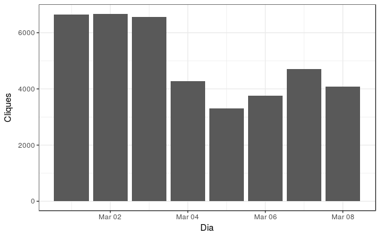

```r
total_cliques <- buscas %>%
    group_by(date)%>%
    summarise(cliques = sum(num_clicks))
ggplot(total_cliques, aes(date, cliques))+
    geom_col() +
    labs(x = "Dia", y = "Cliques")
```

Pode-se perceber picos de cliques nos três primeiros dias, após isso há dois dias de queda e depois uma ligeira crescida no número de cliques, vale salientar que no dia 8 os dados obtidos só mostram os cliques até às 20:24, ou seja, a queda desse dia pode ser por causa que a pesquisa não cobriu o dia todo.

No gráfico a seguir mostramos a taxa de cliques por grupo:

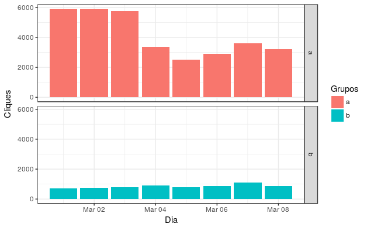

```r
total_cliques <- buscas%>%
    group_by(date, group) %>%
    summarise(cliques = sum(num_clicks))
ggplot(total_cliques, aes(date, cliques, fill = group))+
    geom_col() +
    facet_grid(group ~ .) +
    labs(x = "Dia", y = "Cliques", fill="Grupos")
```

Como pode ser observado no gráfico, há uma diferença grande entre os grupos, em que o grupo **A** tem maior número de cliques, porém com variações maiores. Já o **B** tem as menores taxas de cliques, porém com variação menor do que o **A**.

## Questão 2

Para responder esta pergunta, iremos usar as variáveis **first_click** e **date**. Segue o gráfico da posição do primeiro clique no resultado da busca:

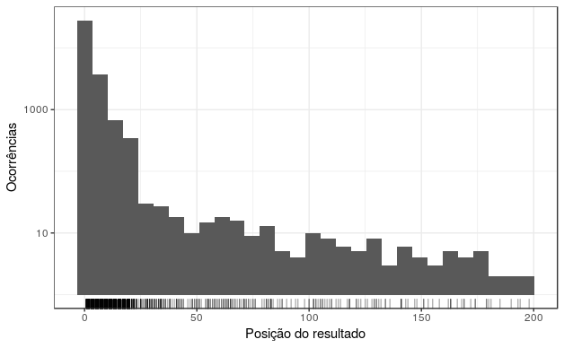

```r
buscas %>%
    filter(first_click <= 200) %>%
    ggplot(aes(x = first_click)) +
    geom_histogram() +
    geom_rug(alpha = .3) +
    scale_y_log10() +
    labs(x = "Posição do resultado", y = "Ocorrências")
```

Optou-se por usar nesse gráfico os resultados das 200 primeiras posições, pois assim facilitaria a visualização do resultado. Com a ajuda da função rug, que coloca linhas abaixo do gráfico para indicar onde há ocorrências, pode-se observar que a maior concentração de cliques ocorrem aproximadamente nas 25 primeiras posições.

A seguir é apresentado o gráfico em relação aos dias:

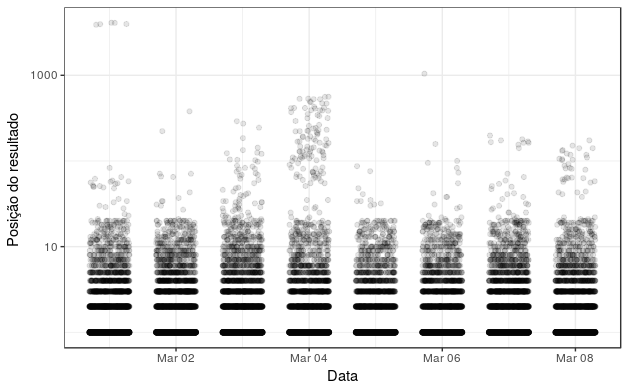

```r
buscas %>%
    ggplot(aes(x = date, y = first_click)) +
    geom_jitter(alpha = .1, width = .3) +
    scale_y_log10() +
    labs(x = "Data", y = "Posição do resultado ")
```

Nesse gráfico optamos por usar todos os resultados coletados, com isso pode-se ter uma noção geral da distribuição em relação aos dias. No geral não há tanta diferença entre os dias, porém vale abordar dois pontos. No dia 04/03 há um aumento nos cliques acima da posição 100 e o outro ponto a falar são os cliques que ocorreram acima da posição 1000, não dar para responder ambos pontos, porém é algo interessante a se relatar.

## Questão 3

Para responder esta pergunta, iremos usar as variáveis **results** e **group**. Obtemos a seguinte visualização:

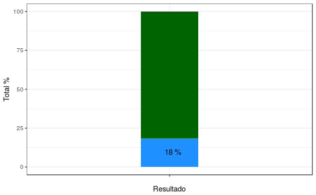

```r
result_0 <- buscas%>%
    filter(results == 0)
result <- buscas%>%
    summarise(total = n())

total_0 <- result_0%>%
    summarise(vazios=n())
merge(result, total_0)%>%
ggplot()+
    geom_col(aes(x="", y =(total/total)*100), fill= "#006400", width = .2)+
    geom_col(aes(x="", y=(vazios/total)*100), fill= "#1E90FF", width = .2)+
    geom_text(aes(x = "", y = (vazios/total)*100, label=paste(trunc((vazios/total)*100), "%")), vjust=3, hjust= .3, color="black", size=4) +
    labs(x = "Resultado", y = "Total %")
```

```r
NA
```

A barra em azul indica o total de resultados zero em relação ao total que está em verde escuro. Como pode ser reparado o total de buscas com retorno zero, é pequeno em relação ao número total de buscas.

Para a segunda parte dessa pergunta, é apreentado o seguinte gráfico:

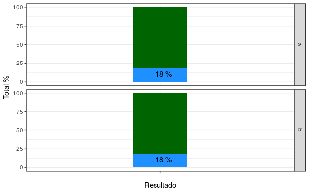

```r
total_0 <- result_0%>%
    group_by(group)%>%
    summarise(vazios=n())
result <- buscas%>%
    group_by(group)%>%
    summarise(total = n())
merge(result, total_0)%>%
ggplot()+
    geom_col(aes(x="", y =(total/total)*100), fill= "#006400", width = .2)+
    geom_col(aes(x="", y=(vazios/total)*100), fill= "#1E90FF", width = .2)+
    facet_grid(group ~ .)+
    geom_text(aes(x = "", y = (vazios/total)*100, label=paste(trunc((vazios/total)*100), "%")), vjust=1.6, hjust= .3, color="black", size=4) +
    labs(x = "Resultado", y = "Total %")
```

Como pode ser visto no gráfico, o resultado é o mesmo quando dividirmos em grupos. Por mais que o grupo **B** ser menos, ambos grupos tem resultados iguais em termos de porcentagem, então nesse aspecto ambos os grupos tiveram resultados iguais.

## Questão 4

Para responder a última pergunta, foi usado às variáveis **session_start_timestamp**, **session_end_timestamp** e **date*. Obetivemos o seguinte gráfico:

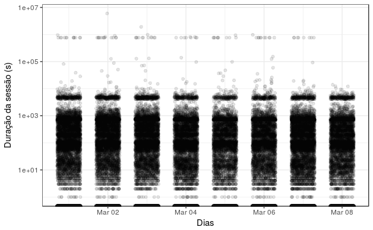

```r
buscas %>%
    group_by(session_id) %>%
    summarise(date_0 = first(date),
              duration = last(session_end_timestamp) - first(session_start_timestamp)) %>%
    ggplot(aes(x = date_0, y = duration)) +
    geom_jitter(alpha = .1, width = .3) +
    scale_y_log10() +
    labs(x = "Dias", y = "Duração da sessão (s)")
```

Esse gráfico apresenta o comportamento dos tempos das sessões em relação ao dia, e como pode ser observado, o comportamento é bastante similar em todos os dias, vale salientar que foi feita uma subtração entre o tempo final e inicial da sessão, para que pudéssemos obter o tempo da sessão.

## Questão 5

Neste relatorio, procuramos responder da melhor forma possível, as perguntas do exercício disponibilizados pelo Wikimedia, utilizamos gráficos de barras, histogramas e de pontos, para facilitar o entendimento dos resultados dos dados obtidos.